# SP_returns

```python
import pylab
import pandas as pd
import numpy as np
import scipy.stats as stats
import matplotlib.pyplot as plt
from IPython.core.display import display, HTML
display(HTML("<style>.container { width:100% !important; }</style>"))
```

```python
data = pd.read_csv('./datafiles/GSPC.csv')
print(data.shape)
data.loc[:, 'date'] = pd.to_datetime(data.Date)
data.set_index('date', inplace=True)
data.drop('Date', axis=1, inplace=True)

# compute return and log return
data.loc[:, 'prev_Close'] = data.Close.shift(1)
data.dropna(inplace=True)
data.loc[:, 'r'] = (data.Close - data.prev_Close)/data.prev_Close
data.loc[:, 'logr'] = np.log(1 + data.r)
```

```
(5031, 7)
```

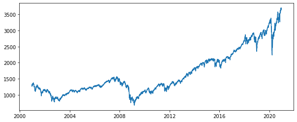

```python
# 20 years' S&P close price, from Yahoo finance
plt.rcParams['figure.figsize'] = (10,4)
plt.plot(data.Close)
```

```
Here, we observe that log(1+r) ~= r for small values:
```

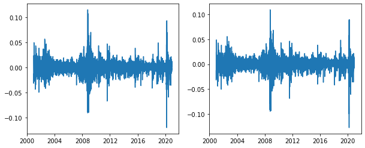

```python
plt.rcParams['figure.figsize'] = (10,4)
plt.subplot(121)
plt.plot(data.r)
plt.subplot(122)
plt.plot(data.logr)
print('Here, we observe that log(1+r) ~= r for small values: ')
```

```
Daily log return:
```

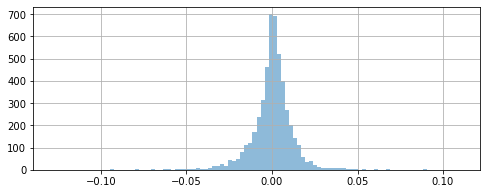

```python
plt.rcParams['figure.figsize']=[8,3]
data.logr.hist(bins=100, alpha=0.5)
print('Daily log return:')
```

As shown above, log returns don't follow a normal distribution! There's a negative skew (which is more pronounced for weekly/monthly data), because in times of panic there are bigger drawdowns.

Next, we attempt to correct for this by using volatility to normalize the return.

```python
def get_vol(s, logr):
    '''
    Compute weighted volatility using using a running sum
    s: decay factor
    '''
    var = 0.0
    lam = 0.0
    var_list = []
    for r in logr:
        lam = lam*s + 1
        var = (1-1.0/lam)*var + (1.0/lam)*r**2
        var_list.append(var)
    return [np.sqrt(x) for x in var_list]
```

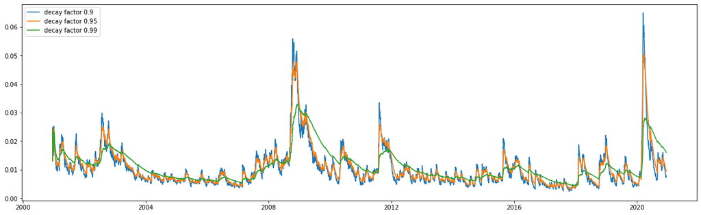

```python
plt.rcParams['figure.figsize'] = (20,6)
counter = 1
for s in [0.9, 0.95, 0.99]:
    vol = get_vol(s, list(data.logr))
    plt.plot(data.index, vol, label = "decay factor {}".format(s))
    data.loc[:, 'norm{}'.format(counter)] = data.logr / vol
    counter += 1
plt.legend()
```

We describe how the running sum advances:

At time i (first line are the returns assuming 0 mean, followed by their weights),

. . . $r_3^{2}$ $r_2^{2}$ $r_1^{2}$

. . . $s^2$ $s$ $1$

At time i+1,

. . . $r_3^{2}$ $r_2^{2}$ $r_1^{2}$ $r_0^{2}$

. . . $s^3$ $s^2$ $s$ $1$

Assuming infinite terms then all the coefficients sum to $\frac{1}{1-s}$. We can show that $V = sV_i + (1-s)r_0^2$. Function *get_vol* carries out this procedure.

Iter 1, the running sum is $r_0^2$

Iter 2, the running sum is $\frac{s}{1+s}V_{old} + \frac{1}{1+s}r_1^2$

Iter 3, the running sum is $\frac{s+s^2}{1+s+s^2}V_{old} + \frac{1}{1+s+s^2}r_2^2$

Having a small (close to 0) $s$ means less weight is given to the previous running sum, (i.e. retaining less memory or *faster decay*) and vice versa.

```
Volatility normalized log returns:
```

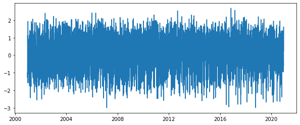

```python
plt.rcParams['figure.figsize'] = (10,4)
plt.plot(data.norm1)
print("Volatility normalized log returns:")
```

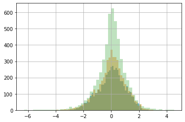

```python
plt.rcParams['figure.figsize'] = (6,4)
data.norm1.hist(bins=50, alpha=0.5)
data.norm2.hist(bins=50, alpha=0.4)
data.norm3.hist(bins=50, alpha=0.3)
```

```
QQ-plot:
```

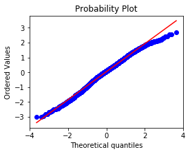

```python
plt.rcParams['figure.figsize']=[4,3]
stats.probplot(data.norm1, dist="norm", plot=pylab)
print('QQ-plot:')
```

Smaller $s$ (i.e. faster decay) works better, as expected.